# Lesson 11: Principal Component Analysis

DS 01-101: In-Depth Introduction to Data Science (Spring 2026)

Author

Affiliation

Hung Tong

Rowan University

## Readings

From **An Introduction to Statistical Learning with Applications in R** by Drs. Gareth James, Daniela Witten, Trevor Hastie, and Rob Tibshirani:

- Unsupervised Learning

The book is freely available at https://www.statlearning.com/

## Topics

- Principal Component Analysis

## Dimensionality Reduction

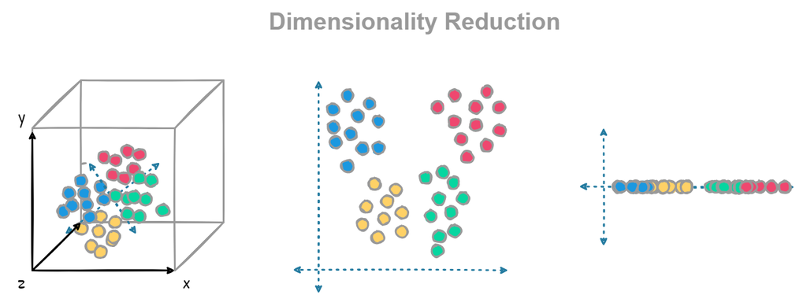

From mlguru.ai

## Principal component analysis

- **Principal component analysis (PCA)** aims to explain the variability of a multivariate dataset using a few special linear combinations of the original variables $X_1, X_2, \dots, X_p$ called principal components.
- Principal component analysis is arguably the most popular dimensionality reduction method.
- A data set with $p$ variables is transformed into a data set with $p$ principal components. Each principal component refers to a new direction or axis that captures as much variability as possible.
- Although $p$ components are required to reproduce the total variability, using the first few principal components is enough to explain most of this variability.
- Geometrically, a linear combination of $p$ variables $X_1, X_2, \dots, X_p$ defines a new direction or axis.
  $$a_1 X_1 + a_2 X_2 + \dots + a_p X_p$$
- A linear combination of $p = 2$ variables $X_1$ and $X_2$ may define a new axis as follows

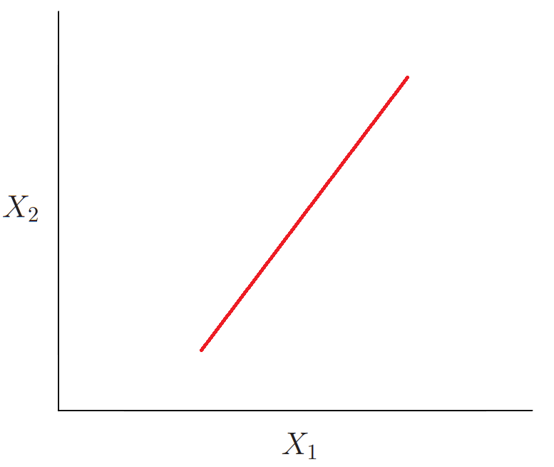

- A linear combination of $p = 3$ variables $X_1, X_2$, and $X_3$ may define a new axis as follows

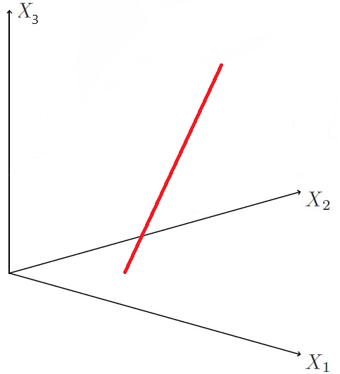

- For a two-dimensional data set, we look for a linear combination $a_1 X_1 + a_2 X_2$ that captures the most variability.

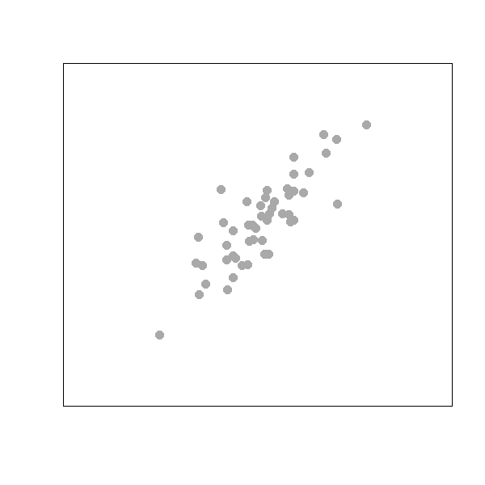

- Many linear combinations (new axes) are available, but the amount of variability they capture varies.

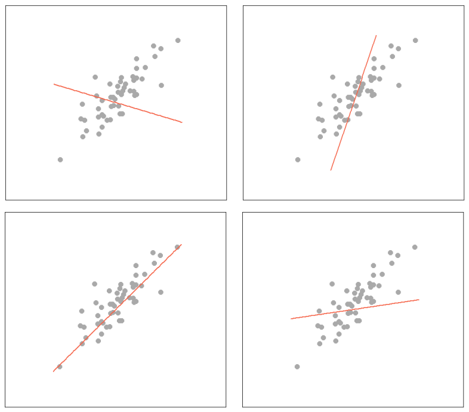

- The linear combination (axis) that captures the most variability is the first principal component.

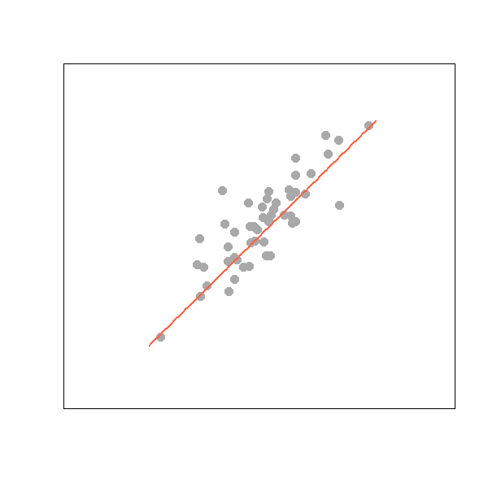

- Another linear combination (axis) that captures most of the remaining variability is the second principal component.

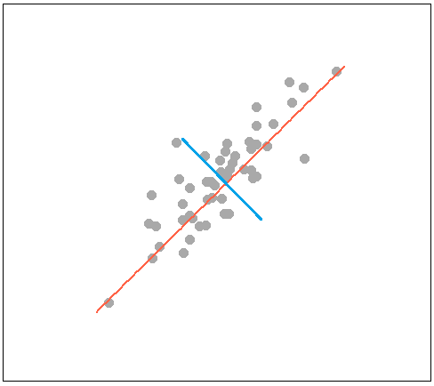

- The **first principal component** is the linear combination of $X_1, X_2, \dots, X_p$ that captures the most variability the data set.
- The **second principal component** is the linear combination $X_1, X_2, \dots, X_p$ that is uncorrelated with the first principal component and captures most of the remaining variability.
- The $j$**th principal component** is the linear combination $X_1, X_2, \dots, X_p$ that is uncorrelated with all previous principal components and captures most of the remaining variability.
- The Italian `wine` data set contains a sample of $178$ bottles: Barolo, Grignolino, and Barbera. For each bottle, the following $13$ chemical and physical properties are measured: Alcohol, Malic, Ash, Alcalinity, Magnesium, Phenols, Flavanoids, Nonflavanoid, Proanthocyanins, Intensity, Hue, OD280, Proline.

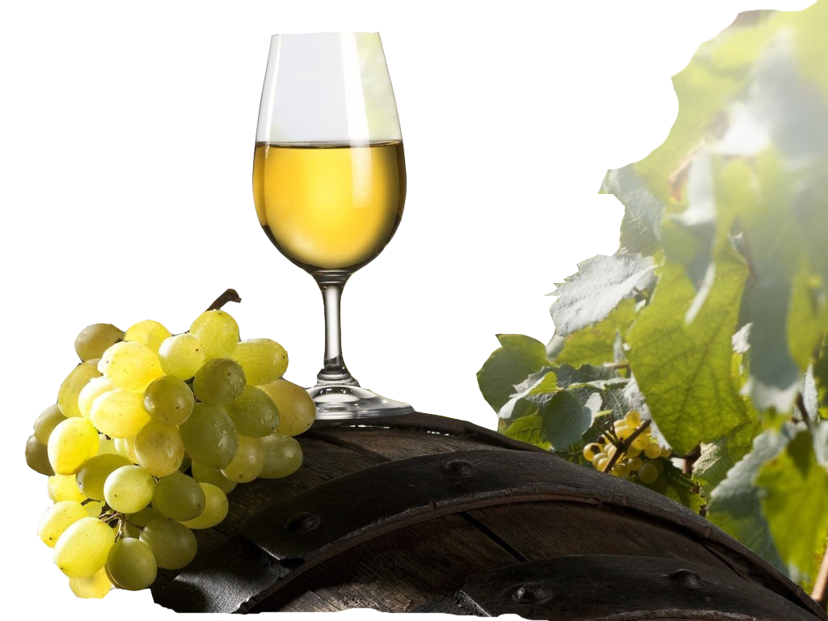

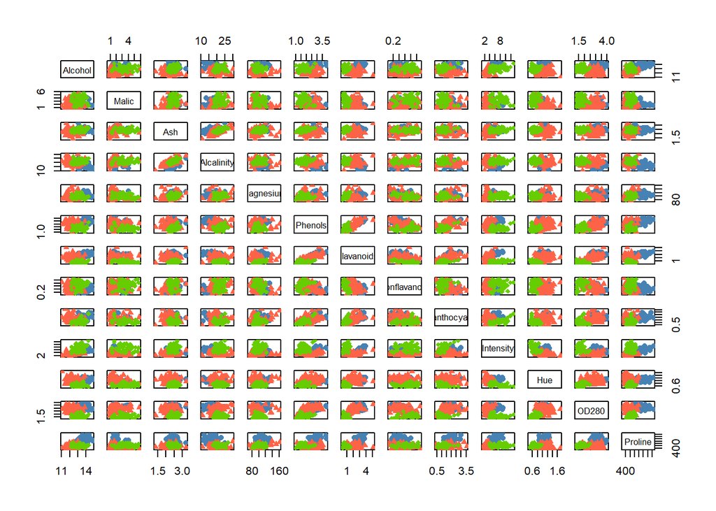

```r
load(url('https://github.com/hungtong/DS-01-101/raw/refs/heads/main/dataset/wine.RData'))

cols <- c('steelblue', 'tomato', 'chartreuse3')
pchs <- c(16, 17, 18)

X <- wine[, -1]

pairs(X, col = cols[wine$Class], pch = pchs[wine$Class])
```

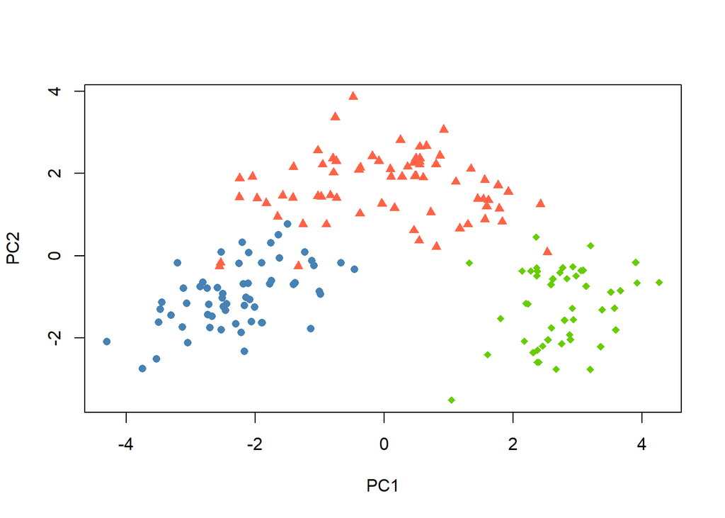

```r
pca <- prcomp(X, scale = TRUE)

plot(pca$x[, 1:2], col = cols[wine$Class], pch = pchs[wine$Class])
```

**Hands-On**

In the `cereal` data set, there are breakfast cereals produced by three different American manufacturers: General Mills (G), Kellogg (K), and Quaker (Q). Conduct a principal component analysis on the data set. Produce the first two principal component scores and visualize them on a two-dimensional scatter plot. Use different colors and plotting symbols to identify the three manufacturers.

**Answer**

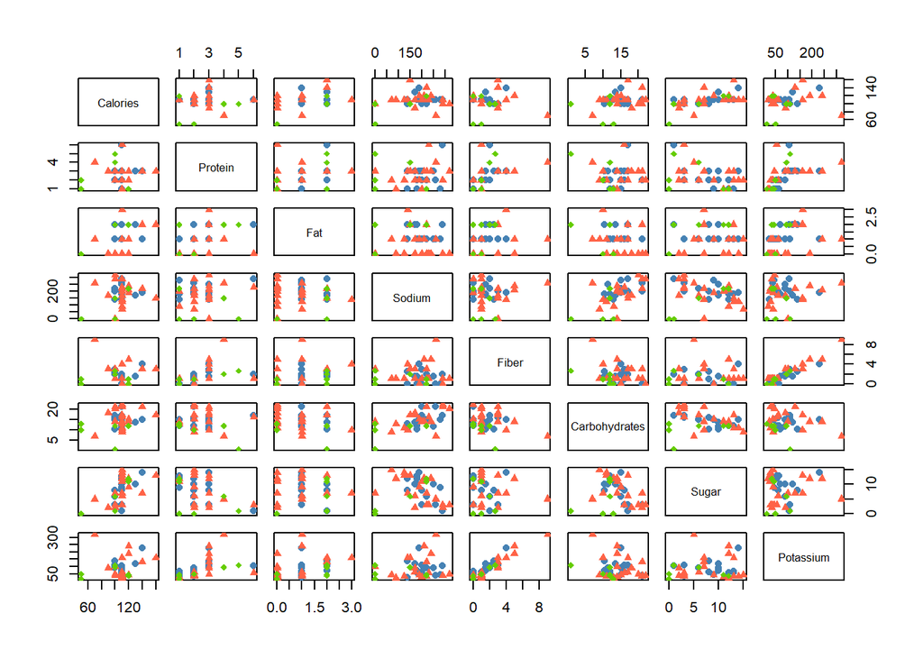

```r
load(url('https://github.com/hungtong/DS-01-101/raw/refs/heads/main/dataset/cereal.rdata'))

X <- cereal[, -(1:2)]

pairs(X, col = cols[cereal$Manufacturer], pch = pchs[cereal$Manufacturer])
```

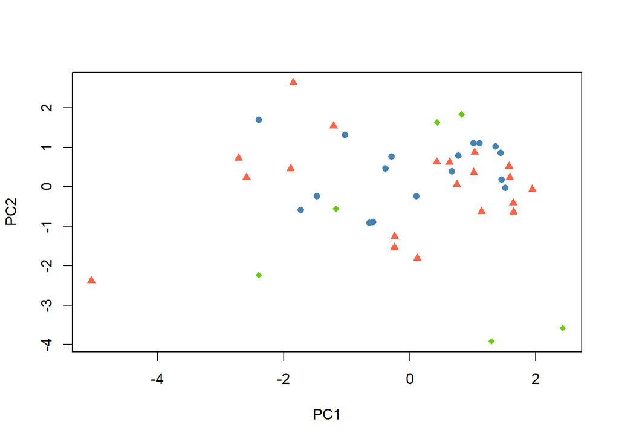

```r
pca <- prcomp(X, scale = TRUE)

plot(pca$x[, 1:2], col = cols[cereal$Manufacturer], pch = pchs[cereal$Manufacturer])
```